# What Makes a Good Theory? How Do We Make a Theory Good?

Rob Davies

## We are learning how to think critically for ourselves

*Active learning* works best even if it sometimes feel challenging

- Active learning is what you do when you ask or answer questions
- We will prompt you sometimes with Activate

**Activate**

What theory is most relevant to your interests?

- How do you know it is a theory?
- What makes it a good theory?

## What we are going to do

People talk about *theories* all the time:

- We are supposed to work with theories to understand human nature
  - We say that this is what we we are doing
  - **But is it?**
- This discussion is designed to help us to think clearly

**Reading**

We borrow the title of the lecture from Olivia Guest’s very helpful article (Guest, 2024)

## Why we need to talk about theories

1. We may or may not be interested in:
- Science or Psychological Science
- Being a scientist or doing research
2. We *will* be interested in using the products of science (the evidence, the insights) in everyday life or in professional practice

## Why we need to talk about theories

We need to do this *here and now* because, typically, we will not have done it before and this neglect causes problems (Proulx & Morey, 2021; Scheel et al., 2021; van Rooij, 2022):

- Excess focus on reporting effects or results without insight
- Claims about things as theories (that are not theories)
- Reports of weak tests of theory that look good but are unhelpful

**Reading**

Critical discussion usually builds on Meehl: we discussed Meehl (1990)’s ideas, previously, see also Meehl (1967) and Meehl (1978)

## Why this will be useful: for life

The evidence or the insights that psychologists produce when they do research often come to us, in everyday life, framed in terms of *ideas* about people and the things we can do:

- Ideas about learning, memory, and cognition
- Ideas about development and individual differences
- Ideas about personality and social processes
- Ideas about the links between brain and cognition

These *ideas* are often (we will see: not always) constructed as *theories*

## Why this will be useful: for students

- Graduates of social or psychological science typically (Proulx & Morey, 2021; Scheel et al., 2021; van Rooij, 2022) train to:
  - Identify a hypothesis
  - Construct a study to test the hypothesis
  - Collect and analyze data to do the test
- We talk about theories in psychological science but *do not* typically consider (1.) what makes the things we talk about theories or (2.) what makes them good or bad
- *This* is why “Demonstrate critical reflection” is hard

## Why this will be challenging

This will be challenging because

1. This work will be new
- If we have not considered what makes a thing a theory or what makes a theory good before, it will be harder to get started (it will get easier)
2. We will need to be watchful
- People sometimes talk about theories when the things they talk about are not theories
- People don’t always talk accurately, reliably, in good faith

## How we will do this

1. What theories are and do
2. Why talking about this stuff is useful
3. How we can build or develop theories
4. What Makes a Good Theory, and How Do We Make a Theory Good?

## How we will do this

Discussions of theory can get *abstract* so I will refer to examples to make the discussion concrete

**Reading**

My examples are based on theory development in research on reading development, dyslexia, and cognitive reading processes in skilled readers

- This is an important policy area to which psychological science has made critical contributions (Castles et al., 2018; Rayner et al., 2001)

## What is a good theory? What makes a theory good?

**Activate**

Think about the psychological science you have read about and are interested in:

- Can you identify a theory in that topic area?
- Where or how is that theory presented or stated?

## What theories are and do

To begin our work, we look at some ways that critical thinkers have identified what a theory *is* and what it does

- We don’t need to be too careful here
- We want to identify some features

## What theories are and do

This definition is compact but does a lot of useful work for us (Guest, 2024; referencing Guest & Martin, 2021):

> A theory is a scientific proposition — described by a collection of natural-language sentences, mathematics, logic, and figures — that introduces causal relations with the aim of describing, explaining, and/or predicting a set of phenomena

## What does theory look like? Targets

Guest (2024):

> a collection of natural-language sentences

Seidenberg & McClelland (1989)’s targets:

1. Theory about recognition and pronunciation of words
2. Skilled readers identify words quickly, activating knowledge about spellings (orthography), meanings (semantics) and sounds (phonology)
3. Beginning readers must acquire these skills: this can be difficult for some children (developmental dyslexia)
4. Deficits in these skills can appear after brain injury (acquired dyslexia)

## Assumptions

Guest (2024):

> a collection of natural-language sentences

Seidenberg & McClelland (1989)’s core assumptions:

> … reading words involves the computation of three types of codes: orthographic, phonological, and semantic.

> Each of these codes is … distributed …

> Processing in the model is … interactive …

> … [and] mediated by connections among the units.

## What does theory look like?

Guest (2024):

> A theory is … figures

[figure not shown]

Figure 1: Seidenberg & McClelland (1989)’s general framework

## What theories are and do

**Key ideas**

When we are looking for the presentation of a theory, we are typically looking for statements identifying:

1. A set of phenomena to be explained
2. A causal mechanism that explains how or why these phenomena occur

## What theories are and do

Guest (2024):

> A theory is a scientific proposition — described by a collection of natural-language sentences, mathematics, logic, and figures — that introduces causal relations with the aim of describing, explaining, and/or predicting a set of phenomena

where

> Phenomenon is a process that generates, or requires, observations, constituting scientists’ perspective on what things appear or seem to be, not how they are.

## What does theory look like? Phenomena

Guest (2024):

> … describing, explaining, and/or predicting a set of phenomena

Seidenberg & McClelland (1989) target phenomena that are observed if we ask adults to read words aloud:

1. In English, the pronunciations of many words is rule-governed but there are exceptions to the rules (compare: regular /gave, pave/ versus exception /have/)
2. Reading aloud exception words is harder than reading regular words
3. This difference is observed to be small in skilled readers’ responses
4. If both exception words and regular words are common in experience (high frequency)

## What does theory look like? Causal explanations

Guest (2024):

> … causal relations

Seidenberg & McClelland (1989)’s causal explanation:

1. Effects like the moderation of the regularity effect by word frequency result
2. In a system comprising a distributed network in which
3. knowledge is encoded through the gradual adaptation of network structure (connection weights) in response to learning experiences
4. where spelling-sound regularity and word frequency are both statistical regularities in the learning environment

## What theories are: where and how they are presented

1. In practice, in our reading, we may be looking for presentations of theory in a journal article (e.g., Seidenberg & McClelland, 1989 appears in *Psychological Review*)
2. We may find that there are multiple versions of a theory (Plaut et al., 1996; Seidenberg & McClelland, 1989)
3. The theory varies over time or to target different phenomena (Harm & Seidenberg, 1999; Harm & Seidenberg, 2004)
4. The theory has competitors with overlapping or distinct targets (e.g., Coltheart et al., 2001)

## Theories, families, and phenomena

[figure not shown]

Figure 2: Theories and families of theories, as theoretical positions, mapped onto the phenomena they address (adapted from Guest (2024), Figure 1)

## Theories, families, and phenomena

In reading and writing about psychology, we may need to *map* (Guest, 2024):

1. Where we find statements of theory
2. What causal relations the theory assumes to explain what phenomena
3. How theories may be grouped into families or fields, where there are multiple theories
4. How a theory relates to other (competing or complementary) theories

[figure not shown]

Figure 3: Theories and families of theories, as theoretical positions, mapped onto the phenomena they address (adapted from Guest (2024), Figure 1)

## Genealogy, contests, competition

In some fields of Psychology, where theories are *well-developed* we see the relationship between theories discussed explicitly

- Seidenberg & McClelland (1989) explain the *precursors* for their account, tracing its *family tree* back to the work of the PDP group in the 1980s (e.g. Rumelhart et al., 1986)
- They take care to explain how their theory is different from alternate accounts (e.g. Morton, 1969)
- They review how different versions of their theory can be grouped together by common principles (Seidenberg & Plaut, 2006)

## What theories are and do

**Activate**

Think about the psychological science you have read about and are interested in:

- Can you identify different theories in your topic area?
  - Where are the different theories presented?
  - How can you tell that the theories are different
- Are different presentations actually presentations of different versions of the same theory or presentations of competing theories?

## Why talking about this stuff is useful

Why are we bothering to think or talk about this stuff? Isn’t it obvious? Is it worth the effort?

## Why talking about this stuff is useful

1. Psychologists often do not know what theories are, or say things are theories when they are not
2. Critical thinkers trace the roots of recent crises back through this *amnesia* about what theories are or do
3. To a blindspot in our education and training

## How do we know there is a problem?

- Over the past 15 years, a series of analyses have been taken to show that some published findings in Psychology cannot be replicated (e.g., Open Science Collaboration, 2015)
  - These results have led to the identification of a *replication crisis*
  - And to proposals for a series of often process-focused practice recommendations (Munafò et al., 2017; Nosek et al., 2018; Vazire, 2018)
- But some argue that the real problem all along was a lack of adequate theory (Proulx & Morey, 2021)

## How do we know there is a problem?

One way we can tell there is a problem is that it is often difficult to identify the key analysis in published papers:

- Students trying to replicate studies could not identify the key statistical for a study (Hawkins et al., 2018)
- Attempts to review literatures found it hard to identify which test results inform which hypotheses and how results affect authors’ conclusions (Scheel, 2022)

## Multiverses: the specification problem

You may remember that, following Meehl (1990), we discussed how to get to a prediction we can test we need:

- A psychological theory about a process or a thing
- Auxiliary assumptions that gets us from the process or thing to what we can observe
- A specific account of what *exactly* we are predicting: is the behaviour going to increase or decrease, and by how much?

## Multiverses: the specification problem

*Multiverse* analyses suggest estimates of psychological effects (phenomena) vary (Silberzahn & Uhlmann, 2015)

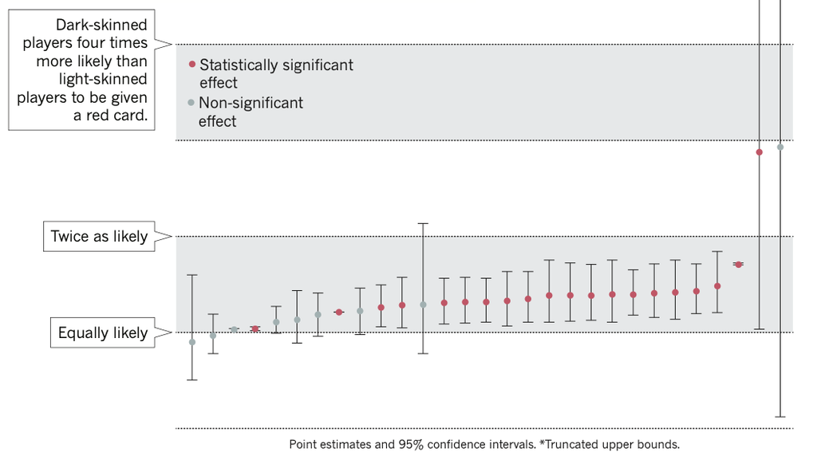

Silberzahn & Uhlmann (2015): Variation in effects estimates by different analysis teams

## Multiverses: the specification problem

But Auspurg & Brüderl (2021) argue this happens when researchers don’t knoww how to interpret the research question

[figure not shown]

Silberzahn & Uhlmann (2015): Variation in effects estimates by different analysis teams

## What is the problem? Theoretical amnesia

Borsboom (2026) argues that what has been going on looks like *theoretical amnesia*: we teach our students or learn how to

1. Form a hypothesis
2. Design a study to test the hypothesis
3. Collect the data and conduct the analysis to do the test
4. Write a narrative report of the test results

## What is the problem? Theoretical amnesia

Borsboom (2026) argues that what has been going on looks like *theoretical amnesia*: we do *not* teach or learn how to

1. Build theories
2. Evaluate theories

## What is the problem? Theoretical amnesia

Borsboom (2026): this is why

> psychology is so hyper-ultra-mega empirical.

We so often see papers that wrap a narrative story about the things people are or do around some statistical test results

## Theories and theory-like objects

- van Rooij (2022) points out that sometimes there are things that we call theories even though they are not theories

**Theories and not theories**

Theories:

- Represent a thing we want to explain, a capacity like the ability to read (Eronen & Bringmann, 2021; van Rooij & Baggio, 2021)
- In terms of a model, expressed in language, or images, or symbols (Guest, 2024; van Rooij & Baggio, 2021)

## Theories and theory-like objects

**Theories and not theories**

Theories *are not* (Devezer, 2024; Fried, 2020; Gigerenzer, 1998; van Rooij, 2022):

- Stories or narratives we might use to describe what we are thinking about
- An acronym or collection of words or a one-word explanation
- A statistical model or data description or summary

## The theory is not the hypothesis is not the statistical test result

**It will help you to keep these things separate**

- **Theories** are accounts of people and the things we do
- **Hypotheses** are based on theories, stated as predictions about how we vary
- **Test results** are aimed at hypotheses, based on observations about how people vary

## The theory is not the hypothesis is not the statistical test result

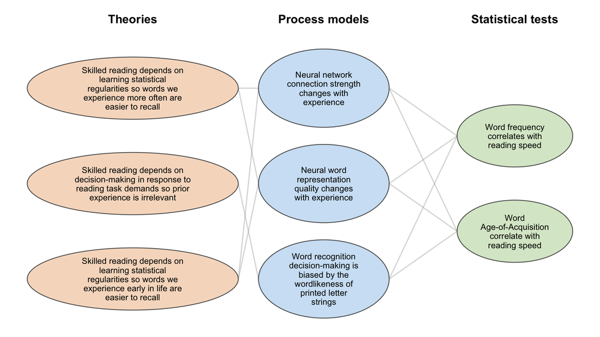

Figure 4: Different theories can imply the same process, and different processes can imply the same statistical test result

## Why talking about this stuff is useful

**Activate**

Think about the psychological science you are interested in:

- Can you identify critical evaluations, in your readings, about the state of theory in your topic area?
- What do people talk about when they talk about (good or bad) theories in the area?

## How we can build theories

So: how do we do this? It will not surprise you to learn that

1. It will (rightly*) be challenging
2. Different thinkers have different ideas about how to best proceed

**Tip**

- * rightly because people are complicated semi-random objects of study

## Resolve the theory crisis by addressing the core challenges

Eronen & Bringmann (2021) argue developing good theories is difficult because:

- We do not have sufficient knowledge of robust phenomena to impose constraints on what theories *can* or *must* explain
- We do not, as a field, invest sufficient energy in improving and validating psychological constructs
- Finding psychological causes is difficult because it is hard to enact manipulations selectively

## If you *could* identify relevant phenomena robustly

Borsboom et al. (2021) identify a theory construction method:

1. Identify relevant phenomena
   - targets for explanation
2. Formulate a prototheory
   - from principles, come up with ideas to explain the phenomena
3. Develop a formal model
   - capture the key ideas in equations or rules, so you can then construct simulations

## If you *could* identify relevant phenomena robustly

4. Check the adequacy of the formal model
- Does a formal account of target phenomena match model-derived expectations?
5. Evaluate the overall worth of the constructed theory
- Deduce hypotheses for testing (Meehl, 1990)
- Assess (1.) the breadth of phenomena the theory can explain and (2.) the economy (simplicity) of the explanation

## Hold on: Focus on capacities

- van Rooij & Baggio (2021): actually, no, psychologists spend too much effort looking for effects
- We don’t need to build collections of robust effects before starting to build theories
- Relevant effects are things we need to explain but they are secondary to our real targets:
  - We really need to focus on explaining our **capacities** for memory, language … which we know about already

## Hold on: Focus on capacities

van Rooij & Baggio (2021):

- The majority of possible effects will be irrelevant for the aims of theory building
  - How can we know which effects are relevant and informative and which ones are not?
- We first need to build candidate theories so that we can determine which effects they imply

## Work through levels of explanation

van Rooij & Baggio (2021) build on Marr (1982/2010) to help us to divide our work into:

- **levels of analysis**
1. **Computational**: what can we do?
2. **Algorithmic**: what process *could* we use to do it?
3. **Implementational**: how *could* the process be implemented?

[figure not shown]

Figure 5: Marr (1982/2010): three levels of analysis; here, adapted for thinking about reading

## The utility of formal models

Guest & Martin (2021): formal models can drive theory development

- Constructing a formal or computational model is helpful
- Because it requires us to commit to, and to make explicit, our theoretical assumptions (compare: Seidenberg & McClelland, 1989)

[figure not shown]

Figure 6: Guest & Martin (2021) (adapted from Figure 2): theory-building hierarchy, from framework to the data used to test specific hypotheses

## The utility of formal models

We progress step-by-step towards increasingly more specific ideas, each next step dependent on the previous step:

- A theory introduces causal relations to describe or explain or predict a set of phenomena
- To produce a specification, we suppose a plausible mechanism
- An implementation will be an instantiation of a model of a candidate mechanisms
- Given our model, we can generate hypotheses
- Hypotheses are narrow testable statements about properties of the world
- that can be measured and evaluated by collecting data and conducting analyses

## How we can build or develop theories

**Activate**

Think about the psychological science you are interested in:

- Can you find an account of the history of the development of theory in your topic area?
- What are the next steps for theory development, in this area?

## What Makes a Good Theory, and How Do We Make a Theory Good?

We reflect on examples of theory to learn how to identify (after Guest, 2024):

- Theory virtues and virtuous theories
- Theory vices and vicious theories

## Guest (2024): *Ontology* of criteria for evaluating theory

1. Metaphysical commitment
   - What parts of theory are not under investigation, but are assumed, asserted, or essential
2. Discursive survival
   - Capacity to be understood by interested non-bad actors, to withstand scrutiny

## Guest (2024): *Ontology* of criteria for evaluating theory

3. Empirical interface
   - How observations relate to, and affect, theory and vice versa
4. Minimising harm
   - Reckoning with the history or potential for harms

## Theory virtues, theory vices

Scientists do theory evalution all the time but *unconsciously*:

- we have our favourite theories, what we choose to spend time on
- and we have theories we criticize, abandon or call *pseudoscientific*

**Tip**

An *ontology* can comprise a formal naming or definition of the categories or properties of, and the relations between, the things we want to talk about

- Here, Guest (2024)’s ontology is helpful because distinguishing categories, properties and relations helps us to grasp the things (theories) we want to evaluate

## Metaphysical commitment

Guest (2024):

- What is the theory?
- What causal relationships does the theory propose?
- What does the theory assert?
- In which field(s) is it embedded? What counts as (mis)use?
- The “triangle model theory” of reading is presented in a series of theoretical papers (Harm & Seidenberg, 1999; Harm & Seidenberg, 2004; Plaut et al., 1996; Seidenberg & McClelland, 1989) reported in cognitive psychology journals like *Psychology Review*
- The “triangle model theory” commits to principles (Seidenberg & Plaut, 2006):
  - cooperative and competitive interactions among simple neuron-like processing units
  - different types of information represented by distributed pattens of activity over different groups of units
  - knowledge encoded as weights on connections between units
  - learning as gradual adjustment of connection weights based on the statistical structure among inputs and outputs

## Discursive survival

Guest (2024):

- The ability to be understood by interested non-bad actors
- To withstand scrutiny within the intended (sub)field(s)
- To negotiate the dialectical landscape (discussion to unearth, resolve, contradictions)
- The “triangle model theory” of reading has frequently been contrasted with alternate or competing theories: compare the Dual Route theory (Coltheart et al., 2001; Pritchard et al., 2018) or CDP++ (Perry et al., 2007; Ziegler et al., 2014)
- Discourse around the rival theories has sometimes been *hot tempered* but is often *productive*:
  - In-depth comparisons of theory principles
  - Progressive development of model specification or implementation information
  - Analyses of what phenomena the theories (implemented as models) can account for (simulate)
  - Refinement of assumptions about the causal psychological mechanisms invoked to do the explanatory work of the theories

## Empirical interface

Guest (2024):

- The potential to explicate the relationship between theory and observation
  - What formalisations are appropriate or necessary for the theory?
  - Which methodologies does the theory use to support or instantiate itself?
  - What evidence does the theory require?
- The various presentations of the different theories have involved:
  - Cognitive process diagrams (box-and-arrow *figures*) and formal statements (math equations) on how network unit activation or learning works
  - Executable code (if shared) in languages like C for running simulations of reading behaviour using model instantiations of theories
  - Analyses of how model-based simulations do or do not capture reading phenomena:
    - observations of effects of different kinds of reading stimuli (e.g. words varying in spelling-sound regularity or consistency) on reading behaviours in children or adults

## Minimising harm

Guest (2024):

- Reckoning with the history of the theory and the potential for future harms
  - Does the theory contain great man theorising?
  - Is the theory exclusionary to certain people or ideas?
  - What is its relationship to previous theories?
  - Does the genealogy of the theory contain harmful ideas?
  - Do ancestral theories remain relevant to the present?
  - What harms have resulted or could result from the use of the theory?

## Minimising harm

Scientists sometimes have a hard time recognizing or acknowledging problematic contexts or histories for our theories, or the potential for harms, but it is productive to reflect on these questions

**Reading**

Castles et al. (2018) discuss the long history of the often heated and obviously consequential argument between advocates of *phonics* and *whole language* approaches to how we teach children to read (see also Rayner et al., 2001)

> strong scientific consensus around the importance of phonics instruction in the initial stages of learning to read

## Minimising harm

It is productive to reflect on these questions

**Reading**

The history of reading research has mostly involved work in English in the UK and USA

- Researchers interested in other languages have hard a hard time publishing observations even on major European languages like Spanish, let alone global majority languages like Mandarin Chinese (e.g., Tse et al., 2017)
- We can see extensions of dual route or connectionist accounts to reading in other languages in the literature (Davies et al., 2013)
- But researchers interested in non-English languages have to speak to theories about reading rooted in ideas about English and observations about English reading phenomena

## Minimising harm

It is productive to reflect on these questions

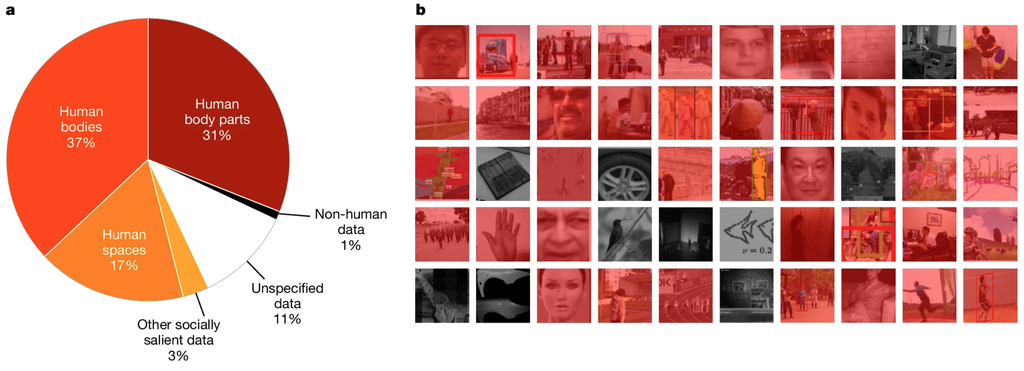

Kalluri et al. (2025): research on computer vision increasingly involve extraction of human body and other socially salient data, enabling surveillance, though the language of research output obscures these applications

## Minimising harm

It is productive to reflect on these questions

**Reading**

We can track the *genealogy* (family history) of contemporary theories about reading back to work like Rumelhart et al. (1986)

- We must resist the temptation to adopt the perspectives or assumptions or language of *Great Men*
  - Geoff Hinton was one of the authors of the Rumelhart et al. (1986) paper and is now “the godfather of AI”
- Reading research might *seem* a long way from potential harms but maybe this work and harmful AI work are at least cousins

## What Makes a Good Theory, and How Do We Make a Theory Good?

**Activate**

Think about the psychological science you are interested in:

- What do people talk about when they talk about (good or bad) theories in the area?
- What in your view make theories good or bad?

## End notes

1. What theories are and do
2. Why talking about this stuff is useful
3. How we can build or develop theories
4. What Makes a Good Theory, and How Do We Make a Theory Good?

## References

Auspurg, K., & Brüderl, J. (2021). Has the Credibility of the Social Sciences Been Credibly Destroyed? Reanalyzing the “Many Analysts, One Data Set” Project. *Socius*, *7*, 23780231211024421. https://doi.org/10.1177/23780231211024421

Borsboom, D. (2026, October 12). *Theoretical amnesia*. Open Science Collaboration. http://osc.centerforopenscience.org/2013/11/20/theoretical-amnesia/

Borsboom, D., van der Maas, H. L. J., Dalege, J., Kievit, R. A., & Haig, B. D. (2021). Theory Construction Methodology: A Practical Framework for Building Theories in Psychology. *Perspectives on Psychological Science*, *16*(4), 756–766. https://doi.org/10.1177/1745691620969647

Castles, A., Rastle, K., & Nation, K. (2018). Ending the Reading Wars: Reading Acquisition From Novice to Expert. *Psychological Science in the Public Interest*, *19*(1), 5–51. https://doi.org/10.1177/1529100618772271

Coltheart, M., Rastle, K., Perry, C., Langdon, R., & Ziegler, J. (2001). DRC: A dual route cascaded model of visual word recognition and reading aloud. *Psychological Review*, *108*(1), 204–256. https://doi.org/10.1037/0033-295X.108.1.204

Davies, R., Barbón, A., & Cuetos, F. (2013). Lexical and semantic age-of-acquisition effects on word naming in Spanish. *Memory and Cognition*, *41*(2). https://doi.org/10.3758/s13421-012-0263-8

Devezer, B. (2024). There are no shortcuts to theory. *Behavioral and Brain Sciences*, *47*, e38. https://doi.org/10.1017/S0140525X23002169

Eronen, M. I., & Bringmann, L. F. (2021). The Theory Crisis in Psychology: How to Move Forward. *Perspectives on Psychological Science*, *16*(4), 779–788. https://doi.org/10.1177/1745691620970586

Fried, E. I. (2020). Lack of Theory Building and Testing Impedes Progress in The Factor and Network Literature. *Psychological Inquiry*, *31*(4), 271–288. https://doi.org/10.1080/1047840X.2020.1853461

Gigerenzer, G. (1998). Surrogates for Theories. *Theory & Psychology*, *8*(2), 195–204. https://doi.org/10.1177/0959354398082006

Guest, O. (2024). What Makes a Good Theory, and How Do We Make a Theory Good? *Computational Brain & Behavior*, *7*, 508–522. https://doi.org/10.1007/s42113-023-00193-2

Guest, O., & Martin, A. E. (2021). How computational modeling can force theory building in psychological science. *Perspectives on Psychological Science*, *16*(4), 789–802. https://doi.org/10.1177/1745691620970585

Harm, M. W., & Seidenberg, M. S. (1999). Phonology, reading acquisition, and dyslexia: Insights from connectionist models. *Psychological Review*, *106*(3), 491–528. https://doi.org/10.1037/0033-295X.106.3.491

Harm, M. W., & Seidenberg, M. S. (2004). Computing the meanings of words in reading: Cooperative division of labor between visual and phonological processes. *Psychological Review*, *111*(3), 662–720. https://doi.org/10.1037/0033-295X.111.3.662

Hawkins, R. X. D., Smith, E. N., Au, C., Arias, J. M., Catapano, R., Hermann, E., Keil, M., Lampinen, A., Raposo, S., Reynolds, J., Salehi, S., Salloum, J., Tan, J., & Frank, M. C. (2018). Improving the Replicability of Psychological Science Through Pedagogy. *Advances in Methods and Practices in Psychological Science*, *1*(1), 7–18. https://doi.org/10.1177/2515245917740427

Kalluri, P. R., Agnew, W., Cheng, M., Owens, K., Soldaini, L., & Birhane, A. (2025). Computer-vision research powers surveillance technology. *Nature*, *643*(8070), 73–79. https://doi.org/10.1038/s41586-025-08972-6

Marr, D. (2010). *Vision: A computational investigation into the human representation and processing of visual information*. MIT Press. (Original work published 1982)

Meehl, P. E. (1990). Why summaries of research on psychological theories are often uninterpretable. *Psychological Reports*, *66*(1), 195–244. https://doi.org/10.2466/pr0.1990.66.1.195

Meehl, P. E. (1978). *Theoretical risks and tabular asterisks: Sir karl, sir ronald, and the slow progress of soft psychology*. *46*(September 1976), 806–834.

Meehl, P. E. (1967). Theory-testing in psychology and physics: A methodological paradox. *Philosophy of Science*, *34*(2), 103–115.

Morton, J. (1969). Interaction of information in word recognition. *Psychological Review*, *76*(2), 165–178. https://doi.org/10.1037/h0027366

Munafò, M. R., Nosek, B. A., Bishop, D. V. M., Button, K. S., Chambers, C. D., Percie Du Sert, N., Simonsohn, U., Wagenmakers, E. J., Ware, J. J., & Ioannidis, J. P. A. (2017). A manifesto for reproducible science. *Nature Human Behaviour*, *1*(1), 1–9. https://doi.org/10.1038/s41562-016-0021

Nosek, B. A., Ebersole, C. R., DeHaven, A. C., & Mellor, D. T. (2018). The preregistration revolution. *Proceedings of the National Academy of Sciences of the United States of America*, *115*(11), 2600–2606. https://doi.org/10.1073/pnas.1708274114

Open Science Collaboration. (2015). Estimating the reproducibility of psychological science. *Science*, *349*(6251), aac4716. https://doi.org/DOI: 10.1126/science.aac4716

Perry, C., Ziegler, J. C., & Zorzi, M. (2007). Nested incremental modeling in the development of computational theories: The CDP+ model of reading aloud. *Psychological Review*, *114*(2), 273–315. https://doi.org/10.1037/0033-295X.114.2.273

Plaut, D. C., Mcclelland, J. L., Seidenberg, M. S., & Patterson, K. (1996). Understanding Normal and Impaired Word Reading : Computational Principles in Quasi-Regular Domains. *Psychological Review*, *103*(1), 56–115. https://doi.org/10.1037/0033-295X.103.1.56

Pritchard, S. C., Coltheart, M., Marinus, E., & Castles, A. (2018). A Computational Model of the Self-Teaching Hypothesis Based on the Dual-Route Cascaded Model of Reading. *Cognitive Science*, *42*(3), 722–770. https://doi.org/10.1111/cogs.12571

Proulx, T., & Morey, R. D. (2021). Beyond Statistical Ritual: Theory in Psychological Science. *Perspectives on Psychological Science*, *16*(4), 671–681. https://doi.org/10.1177/17456916211017098

Rayner, K., Foorman, B. R., Perfetti, C. A., Pesetsky, D., & Seidenberg, M. S. (2001). How psychological science informs the teaching of reading. *Psychological Science in the Public Interest*, *2*(2), 31–74. https://doi.org/10.1111/1529-1006.00004

Rumelhart, D. E., Hinton, G. E., & Williams, R. J. (1986). Learning internal representations by error propagation. In D. E. Rumelhart & J. L. McClelland (Eds.), *Parallel distributed processing: Explorations in the microstructure of cognition* (Vol. 1, pp. 318–364). MIT Press.

Scheel, A. M. (2022). Why most psychological research findings are not even wrong. *Infant and Child Development*, *31*(1), e2295. https://doi.org/10.1002/icd.2295

Scheel, A. M., Tiokhin, L., Isager, P. M., & Lakens, D. (2021). Why hypothesis testers should spend less time testing hypotheses. *Perspectives on Psychological Science*, *16*(4), 744–755. https://doi.org/10.1177/1745691620966795

Seidenberg, M. S., & McClelland, J. L. (1989). A distributed, developmental model of word recognition and naming. *Psychological Review*, *96*(4), 523–568. https://doi.org/10.1037/0033-295X.96.4.523

Seidenberg, M. S., & Plaut, D. C. (2006). Progress in Understanding Word Reading : Data Fitting Versus Theory Building Address for correspondence. In *From Inkmarks to Ideas: Current Issues in Lexical Processing* (pp. 25–49). Psychology Press.

Silberzahn, R., & Uhlmann, E. L. (2015). Crowdsourced research: Many hands make tight work. *Nature*, *526*(7572), 189–191. https://doi.org/10.1038/526189a

Tse, C. S., Yap, M. J., Chan, Y.-L., Sze, W. P., Shaoul, C., & Lin, D. (2017). Lexical decision performance for 25,000+ traditional Chinese two-character compound words. *Behavior Research Methods*, *49*, 1503–1519. https://link.springer.com/article/10.3758/s13428-016-0810-5

van Rooij, I. (2022). Psychological models and their distractors. *Nature Reviews Psychology*, *1*(3), 127–128. https://doi.org/10.1038/s44159-022-00031-5

van Rooij, I., & Baggio, G. (2021). Theory Before the Test: How to Build High-Verisimilitude Explanatory Theories in Psychological Science. *Perspectives on Psychological Science*, *16*(4), 682–697. https://doi.org/10.1177/1745691620970604

Vazire, S. (2018). Implications of the credibility revolution for productivity, creativity, and progress. *Perspectives on Psychological Science*, *13*(4), 411–417. https://doi.org/10.1177/1745691617751884

Ziegler, J. C., Perry, C., & Zorzi, M. (2014). Modelling reading development through phonological decoding and self-teaching: Implications for dyslexia. *Philosophical Transactions of the Royal Society B: Biological Sciences*, *369*(1634), 20120397. https://doi.org/10.1098/rstb.2012.0397